# Tuango - RFM Analysis for Mobile App Push Messaging

- Name: Ziyuan Yan
- GitLab id: @rsm-ziy062

## Setup

Please complete this Rmarkdown document by answering questions 1-13 in `tuango.pdf` on Canvas (week4/). The code block below loads the data you need for this first Rmarkdown file. Create an HTML file with all your results and answers and push both the Rmarkdown and HTML file to GitLab when you are done. All results MUST be reproducible (i.e., the TA and I must be able to recreate the results without changes or errors)

Use “tuango_post.Rmd” to answer Question 14 in `tuango.pdf`

```r
## loading the data - this dataset must NOT be changed
tuango <- readr::read_rds("data/tuango.rds")
```

```r
library(tidyverse)
library(radiant)
```

## Part I: Preliminary and Quintile Analysis

### Question 1

```r
Q1 <- mean(tuango$buyer == "yes")
print(paste0(Q1, " of customers reponsded after the push message."))
```

```
[1] "0.0298084511084009 of customers reponsded after the push message."
```

### Question 2

```r
Q2 <- tuango %>%
  filter(ordersize != 0)

Q2 <- sum(tuango$ordersize)/nrow(Q2)
print(paste0("The average amount spent on the Karaoke deal by customers that bought one (or more) is ", Q2, " RMB."))
```

```
[1] "The average amount spent on the Karaoke deal by customers that bought one (or more) is 202.128760529483 RMB."
```

### Question 3

```r
tuango <- tuango %>%
  mutate(rec_iq = xtile(recency, n = 5),
         freq_iq = xtile(frequency, n = 5, rev = TRUE),
         mon_iq = xtile(monetary, n = 5, rev = TRUE))
```

### Question 4

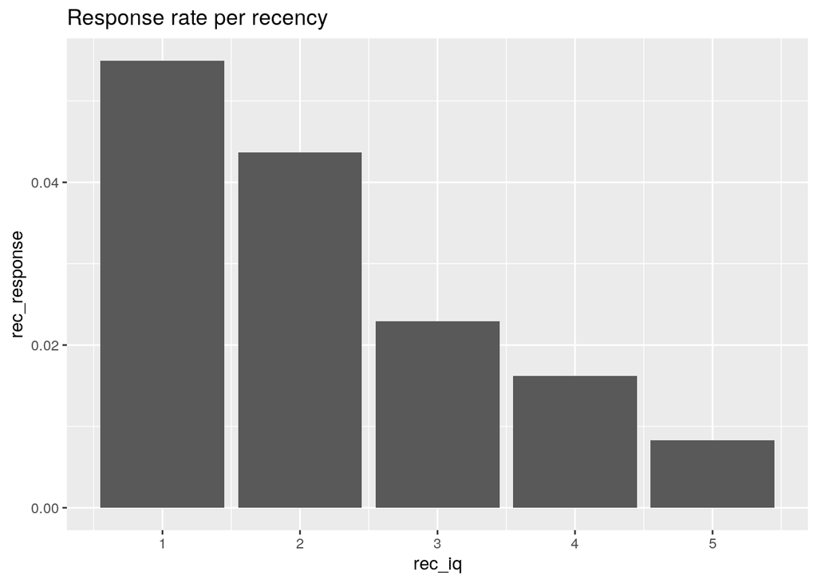

```r
rec_resp <- tuango %>%
  group_by(rec_iq) %>%
  summarize(rec_response = mean(buyer == "yes"))

ggplot(rec_resp, aes(x = rec_iq, y = rec_response)) +
  geom_bar(stat = 'identity') +
  labs(title = "Response rate per recency")
```

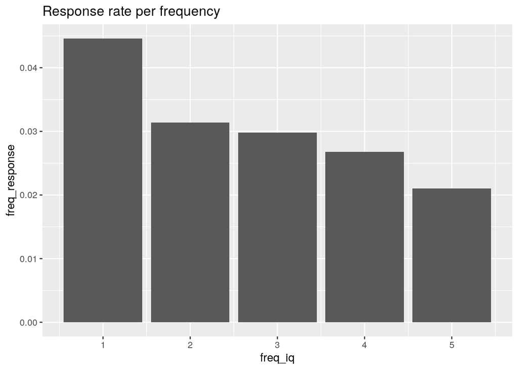

```r
freq_resp <- tuango %>%
  group_by(freq_iq) %>%
  summarize(freq_response = mean(buyer == "yes"))

ggplot(freq_resp, aes(x = freq_iq, y = freq_response)) +
  geom_bar(stat = 'identity') +
  labs(title = "Response rate per frequency")
```

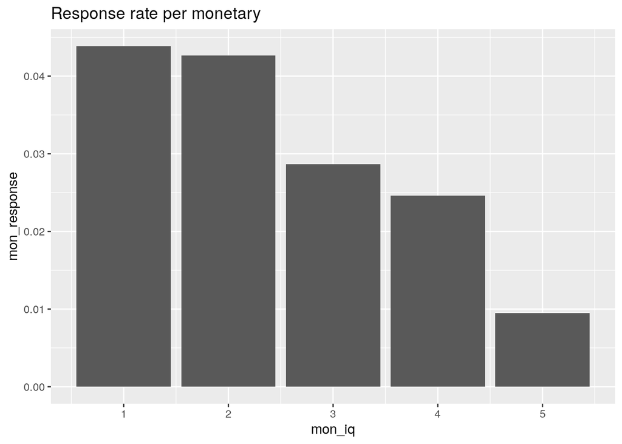

```r
mon_resp <- tuango %>%
  group_by(mon_iq) %>%
  summarize(mon_response = mean(buyer == "yes"))

ggplot(mon_resp, aes(x = mon_iq, y = mon_response)) +
  geom_bar(stat = 'identity') +
  labs(title = "Response rate per monetary")
```

### Question 5

```r
Q5 <- tuango %>%
  filter(buyer == "yes") %>%
  mutate(rec_iq = xtile(recency, n = 5),
         freq_iq = xtile(frequency, n = 5, rev = TRUE),
         mon_iq = xtile(monetary, n = 5, rev = TRUE))
```

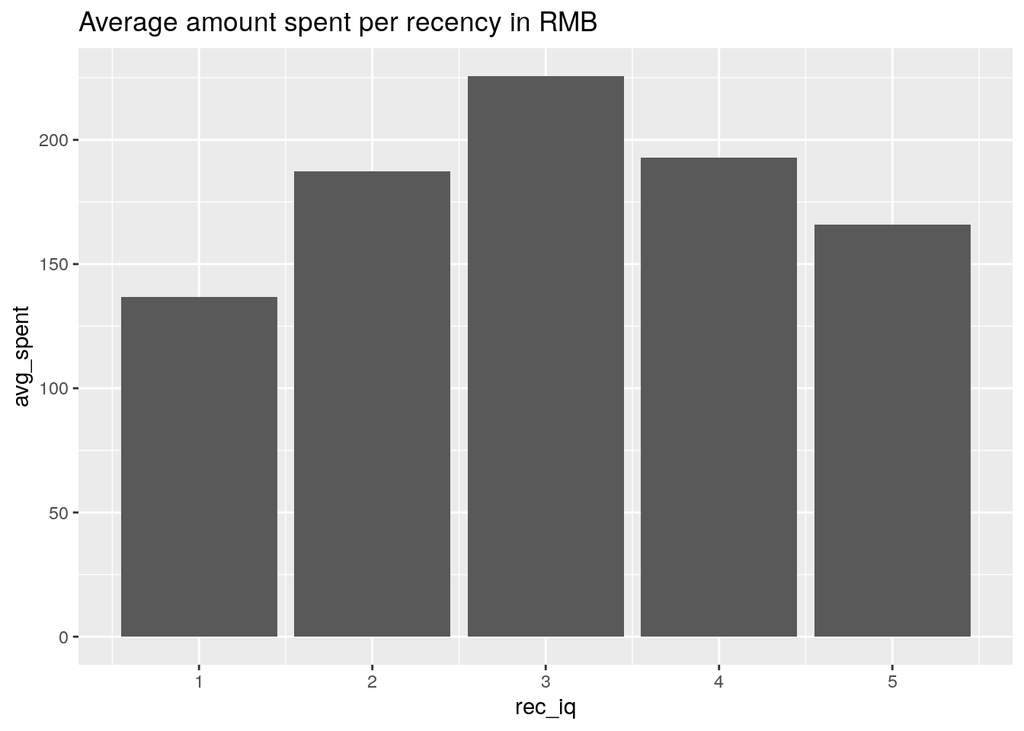

```r
rec_avg_spent <- Q5 %>%
  group_by(rec_iq) %>%
  summarize(avg_spent = mean(monetary))

ggplot(rec_avg_spent, aes(x = rec_iq, y = avg_spent)) +
  geom_bar(stat = 'identity') +
  labs(title = "Average amount spent per recency in RMB")
```

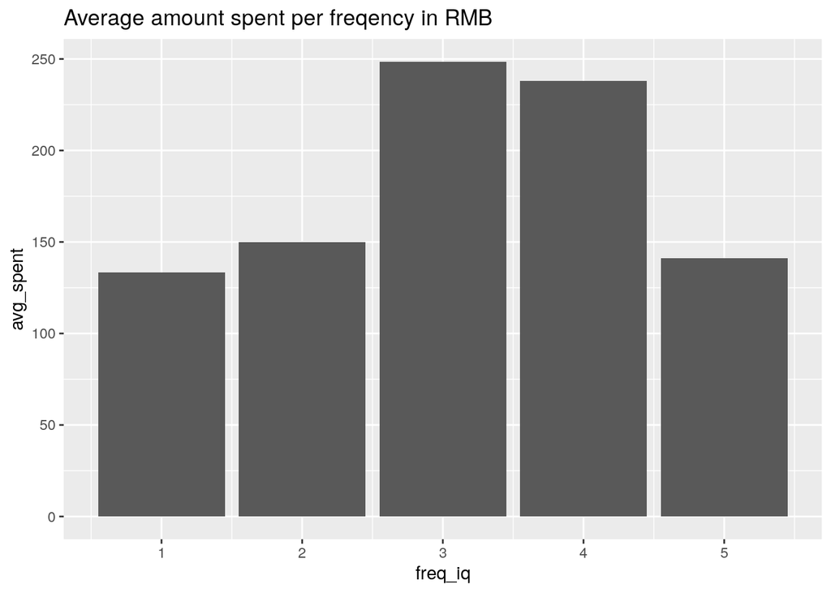

```r
freq_avg_spent <- Q5 %>%
  group_by(freq_iq) %>%
  summarize(avg_spent = mean(monetary))

ggplot(freq_avg_spent, aes(x = freq_iq, y = avg_spent)) +
  geom_bar(stat = 'identity') +
  labs(title = "Average amount spent per freqency in RMB")
```

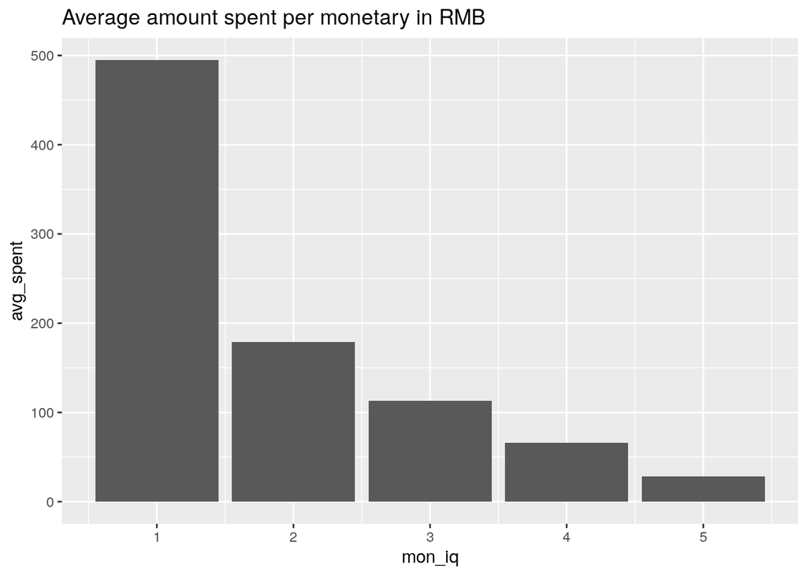

```r
mon_avg_spent <- Q5 %>%
  group_by(mon_iq) %>%
  summarize(avg_spent = mean(monetary))

ggplot(mon_avg_spent, aes(x = mon_iq, y = avg_spent)) +
  geom_bar(stat = 'identity') +
  labs(title = "Average amount spent per monetary in RMB")
```

### Question 6

##### For recency quintiles: Response rate drops as size of the order goes up.

##### For frequency quintiles: Response rate drops relatively slow sompared to recency quintiles as size of the order goes up.

##### For monetary quintiles: Response rate drops as size of the order goes up. mon_iq 1 and 2 have similar response rate.

## Part II: Profitability Analysis

```r
tuango <- tuango %>%
  mutate(rfm_iq = paste0(rec_iq, freq_iq, mon_iq))
```

```r
tuango <- tuango %>%
  group_by(rec_iq) %>%
  mutate(freq_sq = xtile(frequency, n = 5, rev = TRUE)) %>%
  ungroup()

tuango <- tuango %>%
  group_by(rec_iq, freq_sq) %>%
  mutate(mon_sq = xtile(monetary, n = 5, rev = TRUE)) %>%
  ungroup()

tuango <- tuango %>%
  mutate(rfm_sq = paste0(rec_iq, freq_sq, mon_sq))
```

### Question 7

```r
cost_offer <- 2.5
margin_sales <- Q2 * 0.5
break_even <- cost_offer/margin_sales
print(paste0("The break-even response rate is ", break_even, "."))
```

```
[1] "The break-even response rate is 0.0247367073686216."
```

### Question 8

```r
profit <- Q2*250902*Q1*0.5 - cost_offer*250902
ROME <- profit/(cost_offer*250902)
print(paste0("If I offer the deal to all 250,902 remaining customers, the projected profit in RMB is ", profit, " , and the return on marketing expenditures(ROME) is ", ROME, "."))
```

```
[1] "If I offer the deal to all 250,902 remaining customers, the projected profit in RMB is 128605.5 , and the return on marketing expenditures(ROME) is 0.20502905516895."
```

### Question 9

```r
perf_calc <- function(sms, intro) {
  perc_sms <- mean(sms)
  nr_sms <- 250902 * perc_sms # number of sms to send. Only send to the groups where response rate > break-even rate

  dat <- filter(tuango, sms == TRUE) # groups that have response rate > break-even rate
  rep_rate <- mean(dat$buyer == "yes") # response rate in the filtered group
  nr_resp <- nr_sms * rep_rate # number of response

  sms_cost <- 2.5 * nr_sms
  profit <- Q2 * nr_resp * 0.5 - sms_cost
  ROME <- profit / sms_cost

  print(paste0(intro, ", the expected response rate is ", rep_rate, ", the SMS cost is ", sms_cost, ", the projected profit is ", profit, ", and the ROME is ", ROME, "."))
  return(list(response_rate = rep_rate, sms_cost = sms_cost, profit = profit, ROME = ROME))
}
```

#### Independent RFM

```r
## sms TRUE or FALSE
tuango <- tuango %>%
  group_by(rfm_iq) %>%
  mutate(smsto_iq = mean(buyer == "yes") > break_even) %>%
  ungroup()

res_iq <- perf_calc(sms = tuango$smsto_iq, intro = "Based on independent RFM")
```

```
[1] "Based on independent RFM, the expected response rate is 0.0541411537222043, the SMS cost is 279270, the projected profit is 331967.371841155, and the ROME is 1.18869685910107."
```

#### Sequential RFM

```r
## sms TRUE or FALSE
tuango <- tuango %>%
  group_by(rfm_sq) %>%
  mutate(smsto_sq = mean(buyer == "yes") > break_even) %>%
  ungroup()

res_sq <- perf_calc(sms = tuango$smsto_sq, intro = "Based on sequential RFM")
```

```
[1] "Based on sequential RFM, the expected response rate is 0.0568280409508936, the SMS cost is 259335, the projected profit is 336439.52166065, and the ROME is 1.29731629614456."
```

### Question 10

##### rfm_iq generates more TRUE than rfm_sq. The two approaches generally yield the same RFM index for any given customer.

##### Pros of independent quintile: Easy to interpret.

##### Cons of independent quintile: There may be a less even distribution of combined RFM scores with some RFM score segments having no customers.

##### Pros of sequential quintile: Provide a more even distribution of combined RFM scores, and takes into consideration that purchasing behavior (i.e., frequency and monetary) may change over time (recency) due to changes in pricing schemes or seasonal promotions.

##### Cons of sequential quintile: Hard to interpret.

### Question 11

#### Sequential RFM

```r
## sms TRUE or FALSE
Q11 <- tuango %>%
  filter(ordersize != 0) %>%
  group_by(rfm_sq) %>%
  summarize(break_even_sq = 2.5/(mean(ordersize)*0.5))

tuango <- tuango %>%
  left_join(Q11, by = "rfm_sq")

tuango[is.na(tuango)] <- 0

tuango <- tuango %>%
  group_by(rfm_sq) %>%
  mutate(smsto_sq_q11 = mean(buyer == "yes") > break_even_sq) %>%
  ungroup()

res_sq_q11 <- perf_calc(sms = tuango$smsto_sq_q11, intro = "Based on sequential RFM adjusting for the standard error of the response rate in each cell")
```

```
[1] "Based on sequential RFM adjusting for the standard error of the response rate in each cell, the expected response rate is 0.0551980198019802, the SMS cost is 272700, the projected profit is 335808.633574007, and the ROME is 1.23142146525122."
```

### Question 12

#### Independent RFM

```r
## sms TRUE or FALSE
tuango <- tuango %>%
  group_by(rfm_iq) %>%
  mutate(smsto_lbiq = (mean(buyer == "yes") - 1.64 * seprop(buyer == "yes")) > break_even) %>%
  ungroup()

res_iq_q12 <- perf_calc(sms = tuango$smsto_lbiq, intro = "Based on independent RFM adjusting for the standard error of the response rate in each cell")
```

```
[1] "Based on independent RFM adjusting for the standard error of the response rate in each cell, the expected response rate is 0.0756524611826891, the SMS cost is 136215, the projected profit is 280372.375451264, and the ROME is 2.05830764197235."
```

#### Sequential RFM

```r
tuango <- tuango %>%
  group_by(rfm_sq) %>%
  mutate(smsto_lbsq = (mean(buyer == "yes") - 1.64 * seprop(buyer == "yes")) > break_even) %>%
  ungroup()

res_sq_q12 <- perf_calc(sms = tuango$smsto_lbsq, intro = "Based on sequantial RFM adjusting for the standard error of the response rate in each cell")
```

```
[1] "Based on sequantial RFM adjusting for the standard error of the response rate in each cell, the expected response rate is 0.0734920634920635, the SMS cost is 141750, the projected profit is 279385.272563177, and the ROME is 1.97097194048097."
```

### Question 13

```r
## make a tibble (data.frame) with results
dat <- tibble::tibble(
  name = c("Q9_iq", "Q9_sq", "Q11_sq", "Q12_iq", "Q12_sq"),
  Profit = c(res_iq$profit, res_sq$profit, res_sq_q11$profit, res_iq_q12$profit, res_sq_q12$profit),
  ROME = c(res_iq$ROME, res_sq$ROME, res_sq_q11$ROME, res_iq_q12$ROME, res_sq_q12$ROME)
) %>%
  mutate(name = factor(name, levels = name))
```

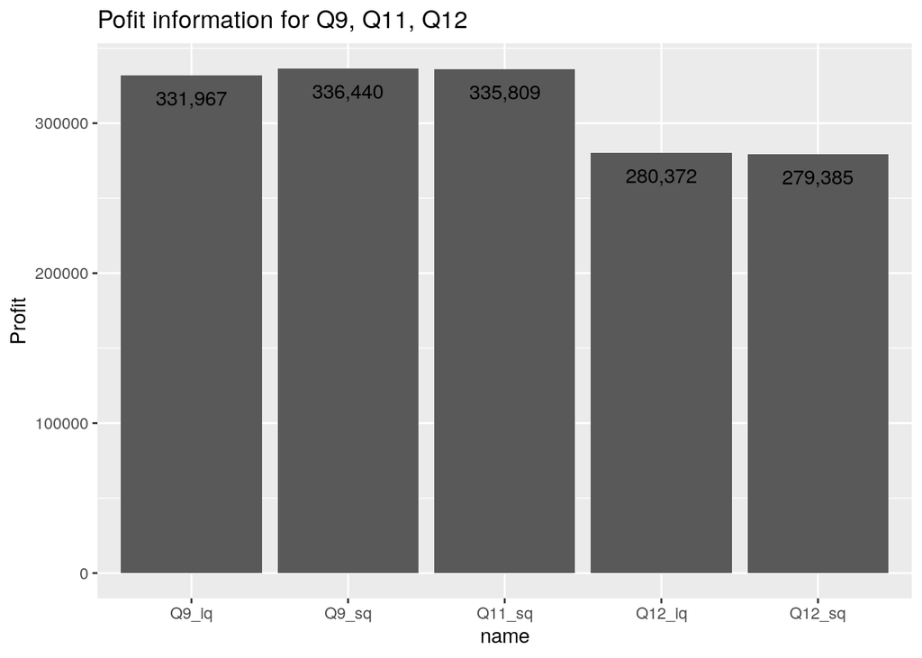

```r
ggplot(dat, aes(x = name, y = Profit)) +
  geom_bar(stat = 'identity') +
  geom_text(aes(label = format_nr(Profit, dec = 0)), vjust = 2) +
  labs(title = "Pofit information for Q9, Q11, Q12")
```

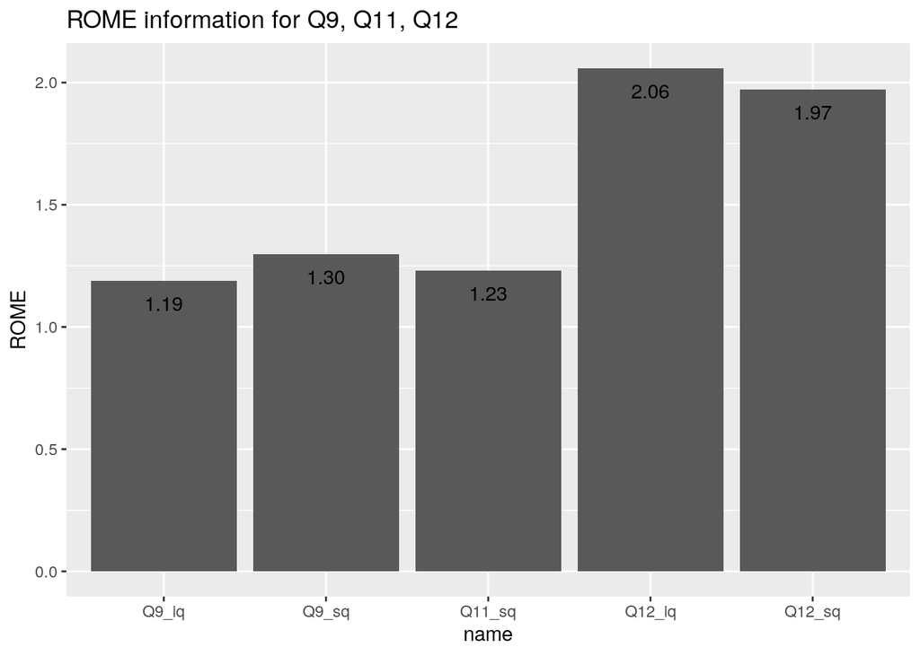

```r
ggplot(dat, aes(x = name, y = ROME)) +
  geom_bar(stat = 'identity') +
  geom_text(aes(label = format_nr(ROME, dec = 2)), vjust = 2) +
  labs(title = "ROME information for Q9, Q11, Q12")
```